# Ensemble Project

## Objective

Using the data collected from existing customers, build a model that will help the marketing team identify potential customers who are relatively more likely to subscribe term deposit and thus increase their hit ratio.

## Attribute Information:

- age:Continuous feature
- job:Type of job (management, technician, entrepreneur, blue-collar, etc.)
- marital: marital status(married, single, divorced)
- education:education level (primary, secondary, tertiary)
- default: has credit in default?
- housing: has housing loan?
- loan: has personal loan?
- balance in account

Related to previous contact:

- contact: contact communication type
- month: last contact month of year
- day: last contact day of the month
- duration: last contact duration, in seconds

Other attributes:

- campaign: number of contacts performed during this campaign and for this client
- pdays: number of days that passed by after the client was last contacted from a previous campaign(-1 tells us the person has not been contacted or contact period is beyond 900 days)
- previous: number of times the client has been contacted before forthe last campaign to subscribe term deposit
- poutcome: outcome of the previous marketing campaign

Output variable (desired target):

- Target: Tell us has the client subscribed a term deposit. (Yes, No)

Github Link: https://github.com/deepak-padmanabhan/PGP-AIML

### Import the datasets and libraries, check datatype, statistical summary, shape, null values or incorrect imputation.

```python
import warnings
warnings.filterwarnings('ignore')
```

```python
#Load Libraries
import pandas as pd
import numpy as np
import matplotlib.pyplot as plt
import seaborn as sns
%matplotlib inline

# Remove scientific notations and display numbers with 2 decimal points instead
pd.options.display.float_format = '{:,.2f}'.format

from sklearn.linear_model import LogisticRegression
#Sklearn package's data splitting function which is based on random function
from sklearn.model_selection import train_test_split
# calculate accuracy measures and confusion matrix
from sklearn import metrics
from sklearn.metrics import confusion_matrix, recall_score, precision_score, f1_score, roc_auc_score,accuracy_score, classification_report
import statsmodels.api as sm
from sklearn import preprocessing
from sklearn.preprocessing import StandardScaler
from sklearn.tree import DecisionTreeClassifier
from sklearn.ensemble import BaggingClassifier
from sklearn.ensemble import AdaBoostClassifier
from sklearn.ensemble import RandomForestClassifier
from sklearn.ensemble import GradientBoostingClassifier
```

### Deliverable-1 Exploratory Data Analysis (Univariate/Multivariate Analysis, Data Treatments)

```python
#Load Dataset
df = pd.read_csv('bank-full.csv')
```

```python
#Print header of the file
df.head()
```

|  | age | job | marital | education | default | balance | housing | loan | contact | day | month | duration | campaign | pdays | previous | poutcome | Target |
| --- | --- | --- | --- | --- | --- | --- | --- | --- | --- | --- | --- | --- | --- | --- | --- | --- | --- |
| 0 | 58 | management | married | tertiary | no | 2143 | yes | no | unknown | 5 | may | 261 | 1 | -1 | 0 | unknown | no |
| 1 | 44 | technician | single | secondary | no | 29 | yes | no | unknown | 5 | may | 151 | 1 | -1 | 0 | unknown | no |
| 2 | 33 | entrepreneur | married | secondary | no | 2 | yes | yes | unknown | 5 | may | 76 | 1 | -1 | 0 | unknown | no |
| 3 | 47 | blue-collar | married | unknown | no | 1506 | yes | no | unknown | 5 | may | 92 | 1 | -1 | 0 | unknown | no |
| 4 | 33 | unknown | single | unknown | no | 1 | no | no | unknown | 5 | may | 198 | 1 | -1 | 0 | unknown | no |

```python
#Check DataTypes
df.dtypes
```

```
age           int64
job          object
marital      object
education    object
default      object
balance       int64
housing      object
loan         object
contact      object
day           int64
month        object
duration      int64
campaign      int64
pdays         int64
previous      int64
poutcome     object
Target       object
dtype: object
```

```python
#Converting the columns with an 'object' datatype into categorical variables

for feature in df.columns: # Loop through all columns in the dataframe
    if df[feature].dtype == 'object': # Only apply for columns with 'object' datatype
        df[feature] = pd.Categorical(df[feature])# Convert to categorical datatype
df.head(10)
```

|  | age | job | marital | education | default | balance | housing | loan | contact | day | month | duration | campaign | pdays | previous | poutcome | Target |
| --- | --- | --- | --- | --- | --- | --- | --- | --- | --- | --- | --- | --- | --- | --- | --- | --- | --- |
| 0 | 58 | management | married | tertiary | no | 2143 | yes | no | unknown | 5 | may | 261 | 1 | -1 | 0 | unknown | no |
| 1 | 44 | technician | single | secondary | no | 29 | yes | no | unknown | 5 | may | 151 | 1 | -1 | 0 | unknown | no |
| 2 | 33 | entrepreneur | married | secondary | no | 2 | yes | yes | unknown | 5 | may | 76 | 1 | -1 | 0 | unknown | no |
| 3 | 47 | blue-collar | married | unknown | no | 1506 | yes | no | unknown | 5 | may | 92 | 1 | -1 | 0 | unknown | no |
| 4 | 33 | unknown | single | unknown | no | 1 | no | no | unknown | 5 | may | 198 | 1 | -1 | 0 | unknown | no |
| 5 | 35 | management | married | tertiary | no | 231 | yes | no | unknown | 5 | may | 139 | 1 | -1 | 0 | unknown | no |
| 6 | 28 | management | single | tertiary | no | 447 | yes | yes | unknown | 5 | may | 217 | 1 | -1 | 0 | unknown | no |
| 7 | 42 | entrepreneur | divorced | tertiary | yes | 2 | yes | no | unknown | 5 | may | 380 | 1 | -1 | 0 | unknown | no |
| 8 | 58 | retired | married | primary | no | 121 | yes | no | unknown | 5 | may | 50 | 1 | -1 | 0 | unknown | no |
| 9 | 43 | technician | single | secondary | no | 593 | yes | no | unknown | 5 | may | 55 | 1 | -1 | 0 | unknown | no |

```python
df.dtypes
```

```
age             int64
job          category
marital      category
education    category
default      category
balance         int64
housing      category
loan         category
contact      category
day             int64
month        category
duration        int64
campaign        int64
pdays           int64
previous        int64
poutcome     category
Target       category
dtype: object
```

###### Insights:

- Job, Marital, Education, Default, Housing, Loan, Contact,Month,Poutcome, Target are categorical
- The remaining columns (Age, Balance, Day, Duration, Campaign, pdays, previous) contain integer numeric values

```python
#Check Shape
df.shape
```

```
(45211, 17)
```

###### Insights: The dataset contains 45211 rows and 17 columns.

```python
#Statistical Summary
df.describe().T
```

|  | count | mean | std | min | 25% | 50% | 75% | max |
| --- | --- | --- | --- | --- | --- | --- | --- | --- |
| age | 45,211.00 | 40.94 | 10.62 | 18.00 | 33.00 | 39.00 | 48.00 | 95.00 |
| balance | 45,211.00 | 1,362.27 | 3,044.77 | -8,019.00 | 72.00 | 448.00 | 1,428.00 | 102,127.00 |
| day | 45,211.00 | 15.81 | 8.32 | 1.00 | 8.00 | 16.00 | 21.00 | 31.00 |
| duration | 45,211.00 | 258.16 | 257.53 | 0.00 | 103.00 | 180.00 | 319.00 | 4,918.00 |
| campaign | 45,211.00 | 2.76 | 3.10 | 1.00 | 1.00 | 2.00 | 3.00 | 63.00 |
| pdays | 45,211.00 | 40.20 | 100.13 | -1.00 | -1.00 | -1.00 | -1.00 | 871.00 |
| previous | 45,211.00 | 0.58 | 2.30 | 0.00 | 0.00 | 0.00 | 0.00 | 275.00 |

###### Insights: Age, Balance, Duration, Campaign, pdays, and previous columns seems to have a lot of outliers

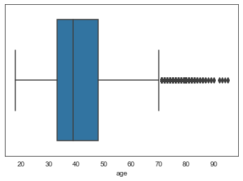

```python
sns.boxplot(df['age'])
```

```python
#Determining the number of outlier values (more than 3 SD) for "age"
upper_age = df['age'].mean()+3*df['age'].std()
num_age = len(df[(df['age']>upper_age)])
print('Number of customers that have an age above', round(upper_age,0), ':', num_age,"(",round(num_age/len(df)*100,1),"%",")")
```

```
Number of customers that have an age above 73.0 : 381 ( 0.8 % )
```

#### Insights: As the number of outliers for "age" is less than 1% I would probably not treat it

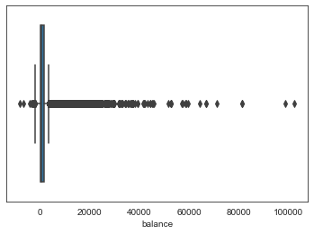

```python
sns.boxplot(df['balance'])
```

```python
#Determining the number of outlier values (more than 3 SD) for "balance"
upper_bal = df['balance'].mean()+3*df['balance'].std()
num_bal = len(df[(df['balance']>upper_bal)])
print('Number of customers that have balance above', round(upper_bal,0), ':', num_bal,"(",round(num_bal/len(df)*100,1),"%",")")

#Determining the number of customers with negative balance
print('Number of clients that have negative balance',':', len(df[(df['balance']< 0)]))
```

```
Number of customers that have balance above 10497.0 : 744 ( 1.6 % )
Number of clients that have negative balance : 3766
```

#### Insights: Balance has negative and outlier values. Will apply standard scaling to treat outliers

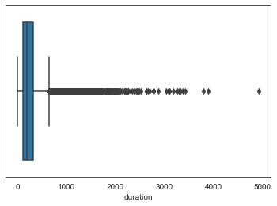

```python
sns.boxplot(df['duration'])
```

```python
#Determining the number of outlier values (more than 3 SD) for "duration"
upper_duration = df['duration'].mean()+3*df['duration'].std()
num_duration = len(df[(df['duration']>upper_duration)])
print('Number of customers that have duration above', round(upper_duration,0), ':', num_duration,"(",round(num_duration/len(df)*100,1),"%",")")
```

```
Number of customers that have duration above 1031.0 : 963 ( 2.1 % )
```

#### Insights: There are 963 outlier values. Will apply standard scaling to treat outliers

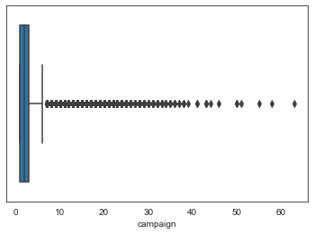

```python
sns.boxplot(df['campaign'])
```

```python
#Determining the number of outlier values (more than 3 SD) for "campaign"
upper_campaign = df['campaign'].mean()+3*df['campaign'].std()
num_campaign = len(df[(df['campaign']>upper_campaign)])
print('Number of customers that have campaign above', round(upper_campaign,0), ':', num_campaign,"(",round(num_campaign/len(df)*100,1),"%",")")
```

```
Number of customers that have campaign above 12.0 : 840 ( 1.9 % )
```

#### Insights: 840 customers contacted more than 12 times. Will apply standardscaling to treat outliers

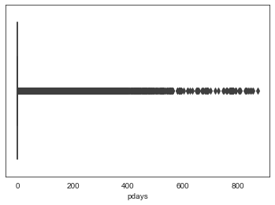

```python
sns.boxplot(df['pdays'])
```

```python
neg_pdays = len(df[(df['pdays']==-1)])
print('Number of -1 values for pdays,', ':', neg_pdays,"(",round(neg_pdays/len(df)*100,1),"%",")")
```

```
Number of -1 values for pdays, : 36954 ( 81.7 % )
```

#### Insights: -1 means the customer either was not contacted or contacted period is beyond 900 days. may drop this attribute depending on feature importance.

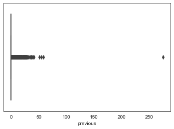

```python
sns.boxplot(df['previous'])
```

```python
#Determining the number of outlier values (more than 3 SD) for "previous"
upper_previous = df['previous'].mean()+3*df['previous'].std()
num_previous = len(df[(df['previous']>upper_previous)])
print('Number of customers that have previous above', round(upper_previous,0), ':', num_previous,"(",round(num_previous/len(df)*100,1),"%",")")
```

```
Number of customers that have previous above 7.0 : 582 ( 1.3 % )
```

```python
print('Number of customers that had 0 contact,', ':', len(df[df['previous'] ==0]),"(",round(len(df[df['previous'] ==0])/len(df)*100,1),"%",")")
```

```
Number of customers that had 0 contact, : 36954 ( 81.7 % )
```

#### Insights: As 82% customers had 0 contact, I would convert the data in the column to categorical: 0 (no contact) and 1 (had contact)

```python
#Check for null or missing values
df.info()
```

```
<class 'pandas.core.frame.DataFrame'>
RangeIndex: 45211 entries, 0 to 45210
Data columns (total 17 columns):
 #   Column     Non-Null Count  Dtype
---  ------     --------------  -----
 0   age        45211 non-null  int64
 1   job        45211 non-null  category
 2   marital    45211 non-null  category
 3   education  45211 non-null  category
 4   default    45211 non-null  category
 5   balance    45211 non-null  int64
 6   housing    45211 non-null  category
 7   loan       45211 non-null  category
 8   contact    45211 non-null  category
 9   day        45211 non-null  int64
 10  month      45211 non-null  category
 11  duration   45211 non-null  int64
 12  campaign   45211 non-null  int64
 13  pdays      45211 non-null  int64
 14  previous   45211 non-null  int64
 15  poutcome   45211 non-null  category
 16  Target     45211 non-null  category
dtypes: category(10), int64(7)
memory usage: 2.8 MB
```

```python
df.isnull().sum()
```

```
age          0
job          0
marital      0
education    0
default      0
balance      0
housing      0
loan         0
contact      0
day          0
month        0
duration     0
campaign     0
pdays        0
previous     0
poutcome     0
Target       0
dtype: int64
```

```python
df.isna().sum()
```

```
age          0
job          0
marital      0
education    0
default      0
balance      0
housing      0
loan         0
contact      0
day          0
month        0
duration     0
campaign     0
pdays        0
previous     0
poutcome     0
Target       0
dtype: int64
```

###### Insights: There are no missing or null values in the dataset

```python
#Unique values in each column
df.nunique()
```

```
age            77
job            12
marital         3
education       4
default         2
balance      7168
housing         2
loan            2
contact         3
day            31
month          12
duration     1573
campaign       48
pdays         559
previous       41
poutcome        4
Target          2
dtype: int64
```

```python
#Value counts of all categorical columns.
for i in ['job','marital','education','default','housing','loan','contact','month','poutcome','Target']:
    print(df[i].value_counts())
```

```
blue-collar      9732
management       9458
technician       7597
admin.           5171
services         4154
retired          2264
self-employed    1579
entrepreneur     1487
unemployed       1303
housemaid        1240
student           938
unknown           288
Name: job, dtype: int64
married     27214
single      12790
divorced     5207
Name: marital, dtype: int64
secondary    23202
tertiary     13301
primary       6851
unknown       1857
Name: education, dtype: int64
no     44396
yes      815
Name: default, dtype: int64
yes    25130
no     20081
Name: housing, dtype: int64
no     37967
yes     7244
Name: loan, dtype: int64
cellular     29285
unknown      13020
telephone     2906
Name: contact, dtype: int64
may    13766
jul     6895
aug     6247
jun     5341
nov     3970
apr     2932
feb     2649
jan     1403
oct      738
sep      579
mar      477
dec      214
Name: month, dtype: int64
unknown    36959
failure     4901
other       1840
success     1511
Name: poutcome, dtype: int64
no     39922
yes     5289
Name: Target, dtype: int64
```

```python
#Normalized Value counts of all categorical columns
for i in ['job','marital','education','default','housing','loan','contact','day','month','poutcome','Target']:
    print(df[i].value_counts(normalize = True))
```

```
blue-collar     0.22
management      0.21
technician      0.17
admin.          0.11
services        0.09
retired         0.05
self-employed   0.03
entrepreneur    0.03
unemployed      0.03
housemaid       0.03
student         0.02
unknown         0.01
Name: job, dtype: float64
married    0.60
single     0.28
divorced   0.12
Name: marital, dtype: float64
secondary   0.51
tertiary    0.29
primary     0.15
unknown     0.04
Name: education, dtype: float64
no    0.98
yes   0.02
Name: default, dtype: float64
yes   0.56
no    0.44
Name: housing, dtype: float64
no    0.84
yes   0.16
Name: loan, dtype: float64
cellular    0.65
unknown     0.29
telephone   0.06
Name: contact, dtype: float64
20   0.06
18   0.05
21   0.04
17   0.04
6    0.04
```

[output cut: 33 more lines]

```
feb   0.06
jan   0.03
oct   0.02
sep   0.01
mar   0.01
dec   0.00
Name: month, dtype: float64
unknown   0.82
failure   0.11
other     0.04
success   0.03
Name: poutcome, dtype: float64
no    0.88
yes   0.12
Name: Target, dtype: float64
```

#### Univariate Analysis

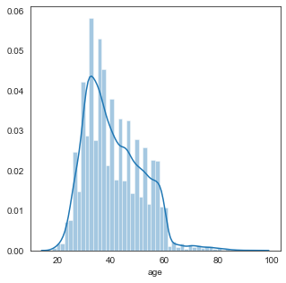

```
Skewness of Data:  0.6848179257252598
```

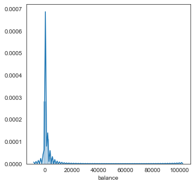

```
Skewness of Data:  8.360308326166326
```

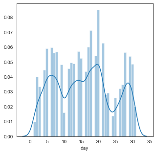

```
Skewness of Data:  0.09307901402122411
```

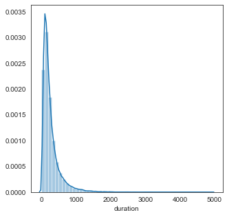

```
Skewness of Data:  3.144318099423456
```

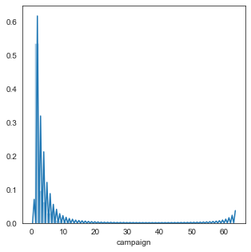

```
Skewness of Data:  4.898650166179674
```

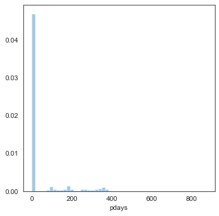

```
Skewness of Data:  2.6157154736563477
```

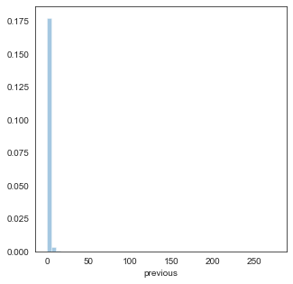

```
Skewness of Data:  41.84645447266292
```

```python
#Univariate Analysis - Distribution and Skewness of Integer columns
for i in ['age','balance','day','duration','campaign', 'pdays','previous']:
    plt.figure(figsize = (5,5))
    sns.distplot(df[i])
    plt.show()
    print('Skewness of Data: ',df[i].skew())
```

```python
df.skew()
```

```
age         0.68
balance     8.36
day         0.09
duration    3.14
campaign    4.90
pdays       2.62
previous   41.85
dtype: float64
```

###### Insights:

- Age seems to be right skewed by a little
- Balance, Duration, Campaign, pdays, and previous are heavily right skewed

#### Bivariate Analysis

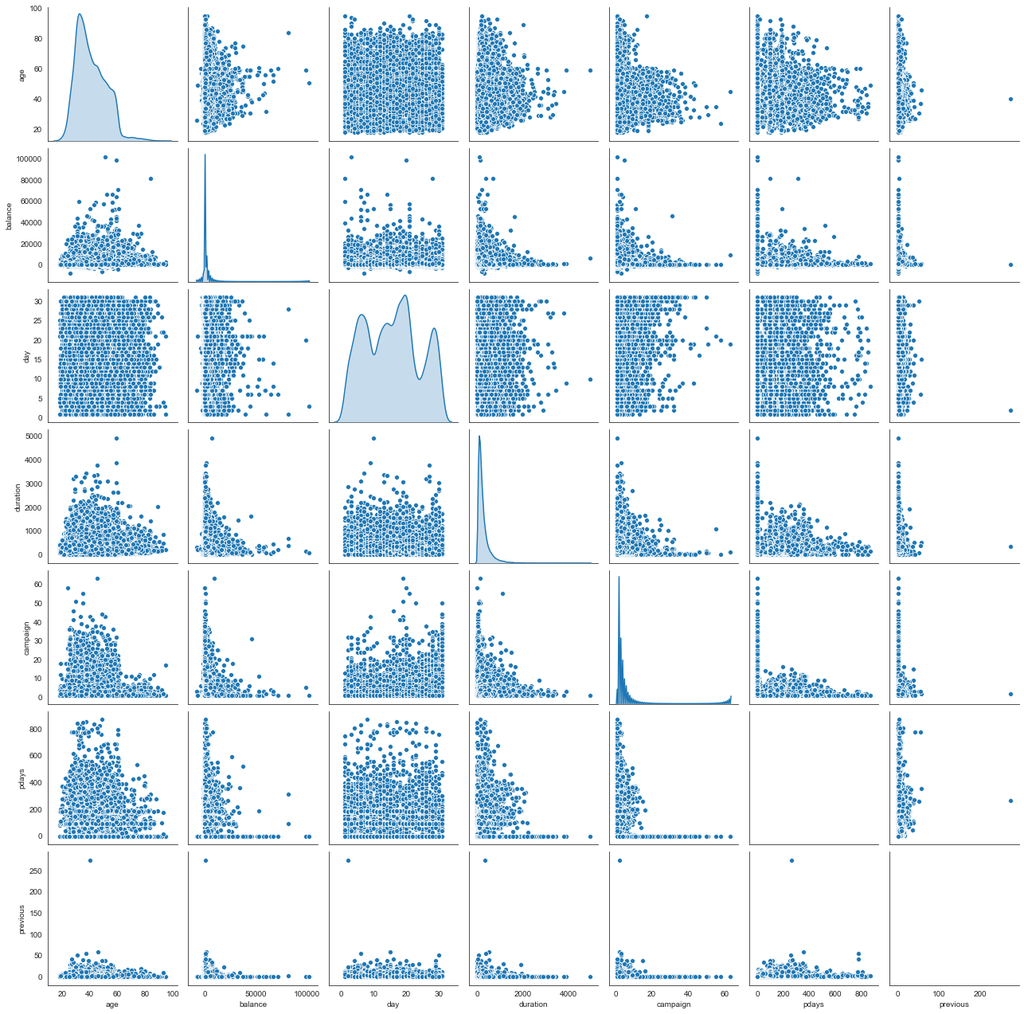

```python
sns.pairplot(df,diag_kind='kde')
plt.show()
```

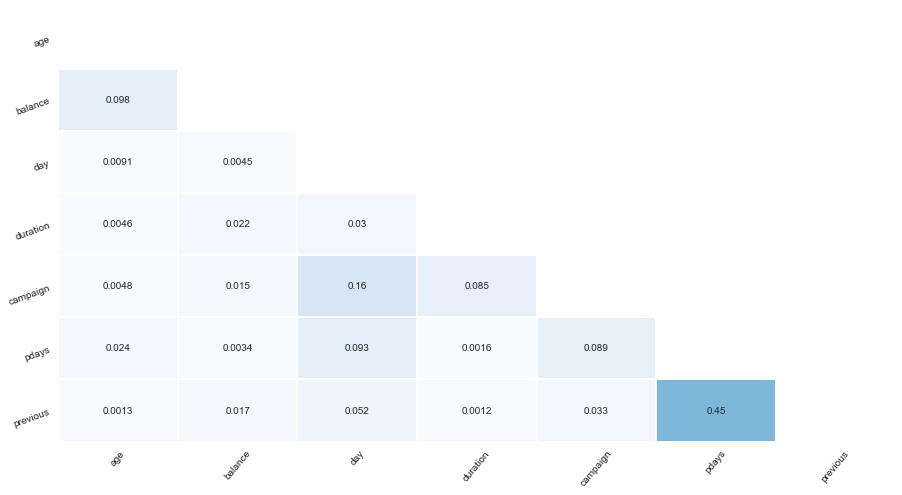

```python
corr = abs(df.corr()) # correlation matrix
lower_triangle = np.tril(corr, k = -1)  # select only the lower triangle of the correlation matrix
mask = lower_triangle == 0  # to mask the upper triangle in the following heatmap

plt.figure(figsize = (15,8))  # setting the figure size
sns.set_style(style = 'white')  # Setting it to white so that we do not see the grid lines
sns.heatmap(lower_triangle, center=0.5, cmap= 'Blues', annot= True, xticklabels = corr.index, yticklabels = corr.columns,
            cbar= False, linewidths= 1, mask = mask)   # Da Heatmap
plt.xticks(rotation = 50)   # Aesthetic purposes
plt.yticks(rotation = 20)   # Aesthetic purposes
plt.show()
```

```python
df.corr()
```

|  | age | balance | day | duration | campaign | pdays | previous |
| --- | --- | --- | --- | --- | --- | --- | --- |
| age | 1.00 | 0.10 | -0.01 | -0.00 | 0.00 | -0.02 | 0.00 |
| balance | 0.10 | 1.00 | 0.00 | 0.02 | -0.01 | 0.00 | 0.02 |
| day | -0.01 | 0.00 | 1.00 | -0.03 | 0.16 | -0.09 | -0.05 |
| duration | -0.00 | 0.02 | -0.03 | 1.00 | -0.08 | -0.00 | 0.00 |
| campaign | 0.00 | -0.01 | 0.16 | -0.08 | 1.00 | -0.09 | -0.03 |
| pdays | -0.02 | 0.00 | -0.09 | -0.00 | -0.09 | 1.00 | 0.45 |
| previous | 0.00 | 0.02 | -0.05 | 0.00 | -0.03 | 0.45 | 1.00 |

###### Insights:

- Weak correlation between independent variables

```python
pd.crosstab(df['job'],df['Target'],normalize="columns")
```

| Target job | no | yes |
| --- | --- | --- |
| admin. | 0.11 | 0.12 |
| blue-collar | 0.23 | 0.13 |
| entrepreneur | 0.03 | 0.02 |
| housemaid | 0.03 | 0.02 |
| management | 0.20 | 0.25 |
| retired | 0.04 | 0.10 |
| self-employed | 0.03 | 0.04 |
| services | 0.09 | 0.07 |
| student | 0.02 | 0.05 |
| technician | 0.17 | 0.16 |
| unemployed | 0.03 | 0.04 |
| unknown | 0.01 | 0.01 |

```python
pd.crosstab(df['marital'],df['Target'], normalize="columns")
```

| Target marital | no | yes |
| --- | --- | --- |
| divorced | 0.11 | 0.12 |
| married | 0.61 | 0.52 |
| single | 0.27 | 0.36 |

```python
pd.crosstab(df['education'],df['Target'],normalize="columns")
```

| Target education | no | yes |
| --- | --- | --- |
| primary | 0.16 | 0.11 |
| secondary | 0.52 | 0.46 |
| tertiary | 0.28 | 0.38 |
| unknown | 0.04 | 0.05 |

```python
pd.crosstab(df['default'],df['Target'],normalize="columns")
```

| Target default | no | yes |
| --- | --- | --- |
| no | 0.98 | 0.99 |
| yes | 0.02 | 0.01 |

```python
pd.crosstab(df['housing'],df['Target'],normalize="columns")
```

| Target housing | no | yes |
| --- | --- | --- |
| no | 0.42 | 0.63 |
| yes | 0.58 | 0.37 |

#### Insight: Most of the consumers who subscribed for term deposit did not have a housing loan

```python
pd.crosstab(df['loan'],df['Target'],normalize="columns")
```

| Target loan | no | yes |
| --- | --- | --- |
| no | 0.83 | 0.91 |
| yes | 0.17 | 0.09 |

```python
pd.crosstab(df['contact'],df['Target'],normalize="columns")
```

| Target contact | no | yes |
| --- | --- | --- |
| cellular | 0.62 | 0.83 |
| telephone | 0.06 | 0.07 |
| unknown | 0.31 | 0.10 |

```python
pd.crosstab(df['poutcome'],df['Target'],normalize="columns")
```

| Target poutcome | no | yes |
| --- | --- | --- |
| failure | 0.11 | 0.12 |
| other | 0.04 | 0.06 |
| success | 0.01 | 0.18 |
| unknown | 0.84 | 0.64 |

```python
pd.crosstab(df['day'],df['Target'],normalize="columns")
```

| Target day | no | yes |
| --- | --- | --- |
| 1 | 0.01 | 0.02 |
| 2 | 0.03 | 0.03 |
| 3 | 0.02 | 0.03 |
| 4 | 0.03 | 0.04 |
| 5 | 0.04 | 0.04 |
| 6 | 0.04 | 0.03 |
| 7 | 0.04 | 0.03 |
| 8 | 0.04 | 0.04 |
| 9 | 0.03 | 0.03 |
| 10 | 0.01 | 0.02 |
| 11 | 0.03 | 0.03 |
| 12 | 0.03 | 0.05 |
| 13 | 0.03 | 0.05 |
| 14 | 0.04 | 0.04 |
| 15 | 0.04 | 0.04 |
| 16 | 0.03 | 0.04 |
| 17 | 0.04 | 0.03 |
| 18 | 0.05 | 0.04 |
| 19 | 0.04 | 0.02 |
| 20 | 0.06 | 0.04 |
| 21 | 0.05 | 0.04 |
| 22 | 0.02 | 0.03 |
| 23 | 0.02 | 0.02 |
| 24 | 0.01 | 0.01 |
| 25 | 0.02 | 0.03 |
| 26 | 0.02 | 0.02 |
| 27 | 0.02 | 0.03 |
| 28 | 0.04 | 0.03 |
| 29 | 0.04 | 0.02 |
| 30 | 0.03 | 0.05 |
| 31 | 0.01 | 0.01 |

```python
pd.crosstab(df['month'],df['Target'],normalize="columns")
```

| Target month | no | yes |
| --- | --- | --- |
| apr | 0.06 | 0.11 |
| aug | 0.14 | 0.13 |
| dec | 0.00 | 0.02 |
| feb | 0.06 | 0.08 |
| jan | 0.03 | 0.03 |
| jul | 0.16 | 0.12 |
| jun | 0.12 | 0.10 |
| mar | 0.01 | 0.05 |
| may | 0.32 | 0.17 |
| nov | 0.09 | 0.08 |
| oct | 0.01 | 0.06 |
| sep | 0.01 | 0.05 |

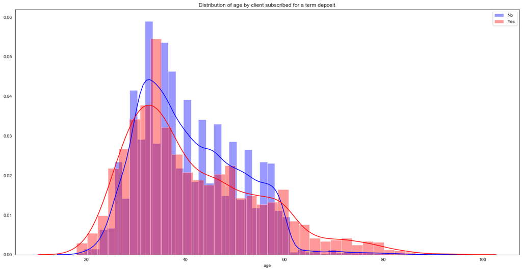

```python
plt.figure(figsize=(20,10))
plt.title('Distribution of age by client subscribed for a term deposit')
sns.distplot(df[df['Target']=="no"]['age'],color='b',label= "No")
sns.distplot(df[df['Target']=="yes"]['age'],color='r',label="Yes")
plt.legend()
plt.show()
```

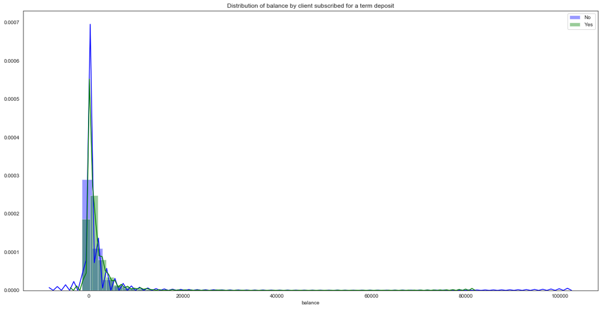

```python
plt.figure(figsize=(20,10))
plt.title('Distribution of balance by client subscribed for a term deposit')
sns.distplot(df[df['Target']=="no"]['balance'],color='b',label= "No")
sns.distplot(df[df['Target']=="yes"]['balance'],color='g',label="Yes")
plt.legend()
plt.show()
```

###### Insights: The distribution of balance are very similar. **Balance may be dropped**

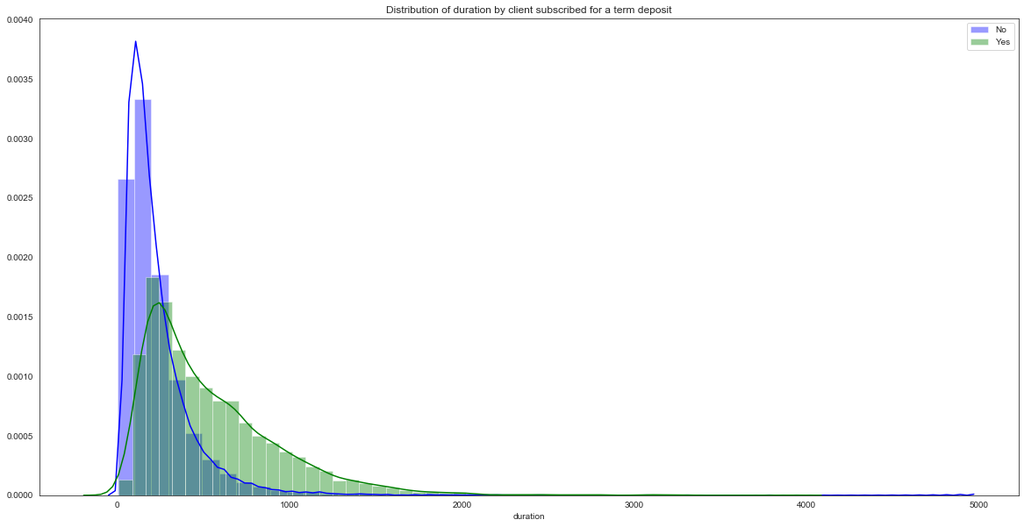

```python
plt.figure(figsize=(20,10))
plt.title('Distribution of duration by client subscribed for a term deposit')
sns.distplot(df[df['Target']=="no"]['duration'],color='b',label= "No")
sns.distplot(df[df['Target']=="yes"]['duration'],color='g',label="Yes")
plt.legend()
plt.show()
```

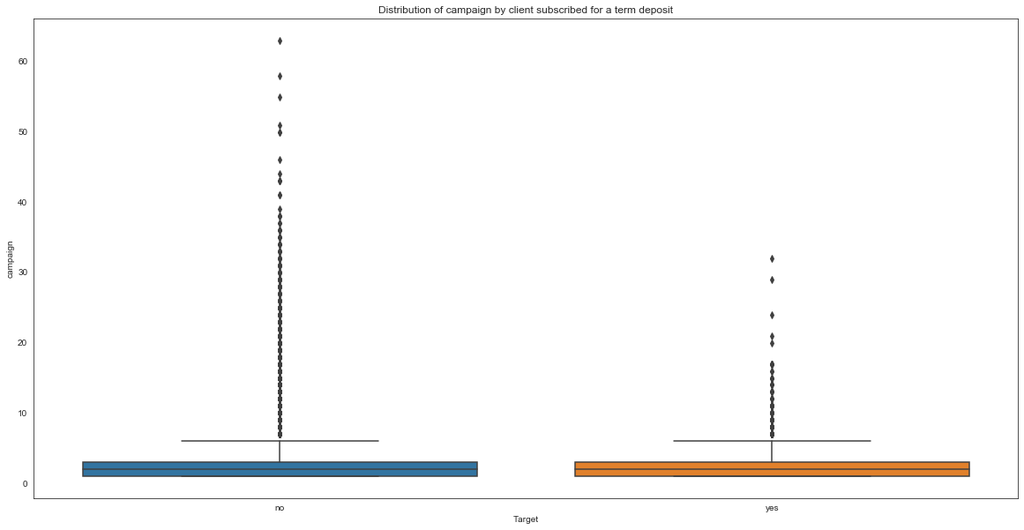

```python
plt.figure(figsize=(20,10))
plt.title('Distribution of campaign by client subscribed for a term deposit')
sns.boxplot(df['Target'], df['campaign']);
```

###### Insights: The distribution of campaign are very similar. **Campaign may be dropped**

### Deliverable-2 Prepare the data for analytics

```python
#Create a "quarter" column based on "month"
#df['quarter'] = df['month'].replace({'jan': '1', 'feb': '1', 'mar': '1',
#                                          'apr': '2', 'may': '2', 'jun': '2',
#                                          'jul': '3', 'aug': '3', 'sep': '3',
#                                          'oct': '4', 'nov': '4', 'dec': '4'})
#pd.crosstab(df['Target'], df['quarter'],normalize='columns')
```

```python
df.head()
```

|  | age | job | marital | education | default | balance | housing | loan | contact | day | month | duration | campaign | pdays | previous | poutcome | Target |
| --- | --- | --- | --- | --- | --- | --- | --- | --- | --- | --- | --- | --- | --- | --- | --- | --- | --- |
| 0 | 58 | management | married | tertiary | no | 2143 | yes | no | unknown | 5 | may | 261 | 1 | -1 | 0 | unknown | no |
| 1 | 44 | technician | single | secondary | no | 29 | yes | no | unknown | 5 | may | 151 | 1 | -1 | 0 | unknown | no |
| 2 | 33 | entrepreneur | married | secondary | no | 2 | yes | yes | unknown | 5 | may | 76 | 1 | -1 | 0 | unknown | no |
| 3 | 47 | blue-collar | married | unknown | no | 1506 | yes | no | unknown | 5 | may | 92 | 1 | -1 | 0 | unknown | no |
| 4 | 33 | unknown | single | unknown | no | 1 | no | no | unknown | 5 | may | 198 | 1 | -1 | 0 | unknown | no |

```python
#Replacing values in Education, Housing, Default, Loan, and Target columns to make it ordinal
ReplaceCols = {
                "education": {"primary": 1, "secondary":2 , "tertiary": 3, "unknown": -1},
                "housing":  {"no": 0, "yes": 1 },
                "default": {"no": 0, "yes": 1 },
                "loan": {"no": 0, "yes": 1 },
                "Target":  {"no": 0, "yes": 1 }
               }
df.replace(ReplaceCols,inplace=True)
df.head()
```

|  | age | job | marital | education | default | balance | housing | loan | contact | day | month | duration | campaign | pdays | previous | poutcome | Target |
| --- | --- | --- | --- | --- | --- | --- | --- | --- | --- | --- | --- | --- | --- | --- | --- | --- | --- |
| 0 | 58 | management | married | 3 | 0 | 2143 | 1 | 0 | unknown | 5 | may | 261 | 1 | -1 | 0 | unknown | 0 |
| 1 | 44 | technician | single | 2 | 0 | 29 | 1 | 0 | unknown | 5 | may | 151 | 1 | -1 | 0 | unknown | 0 |
| 2 | 33 | entrepreneur | married | 2 | 0 | 2 | 1 | 1 | unknown | 5 | may | 76 | 1 | -1 | 0 | unknown | 0 |
| 3 | 47 | blue-collar | married | -1 | 0 | 1506 | 1 | 0 | unknown | 5 | may | 92 | 1 | -1 | 0 | unknown | 0 |
| 4 | 33 | unknown | single | -1 | 0 | 1 | 0 | 0 | unknown | 5 | may | 198 | 1 | -1 | 0 | unknown | 0 |

```python
#Dropping rows with education as unknown
df = df[df['education'] != -1]
```

```python
#df = df[df['contact'] != 'unknown']
```

```python
#Applying One Hot Encoding for Job, Marital, Month, and Contact columns
df = pd.get_dummies(df, columns=['job','marital','month','contact'],drop_first=True)
```

```python
df.head()
```

|  | age | education | default | balance | housing | loan | day | duration | campaign | pdays | ... | month_jan | month_jul | month_jun | month_mar | month_may | month_nov | month_oct | month_sep | contact_telephone | contact_unknown |
| --- | --- | --- | --- | --- | --- | --- | --- | --- | --- | --- | --- | --- | --- | --- | --- | --- | --- | --- | --- | --- | --- |
| 0 | 58 | 3 | 0 | 2143 | 1 | 0 | 5 | 261 | 1 | -1 | ... | 0 | 0 | 0 | 0 | 1 | 0 | 0 | 0 | 0 | 1 |
| 1 | 44 | 2 | 0 | 29 | 1 | 0 | 5 | 151 | 1 | -1 | ... | 0 | 0 | 0 | 0 | 1 | 0 | 0 | 0 | 0 | 1 |
| 2 | 33 | 2 | 0 | 2 | 1 | 1 | 5 | 76 | 1 | -1 | ... | 0 | 0 | 0 | 0 | 1 | 0 | 0 | 0 | 0 | 1 |
| 5 | 35 | 3 | 0 | 231 | 1 | 0 | 5 | 139 | 1 | -1 | ... | 0 | 0 | 0 | 0 | 1 | 0 | 0 | 0 | 0 | 1 |
| 6 | 28 | 3 | 0 | 447 | 1 | 1 | 5 | 217 | 1 | -1 | ... | 0 | 0 | 0 | 0 | 1 | 0 | 0 | 0 | 0 | 1 |

5 rows × 39 columns

```python
#Convert "previous" to categorical
df['previous'].mask(df['previous'] > 0,1,inplace = True)
df['previous'].value_counts()
```

```
0    35420
1     7934
Name: previous, dtype: int64
```

```python
df.dtypes
```

```
age                     int64
education               int64
default                 int64
balance                 int64
housing                 int64
loan                    int64
day                     int64
duration                int64
campaign                int64
pdays                   int64
previous                int64
poutcome             category
Target                  int64
job_blue-collar         uint8
job_entrepreneur        uint8
job_housemaid           uint8
job_management          uint8
job_retired             uint8
job_self-employed       uint8
job_services            uint8
job_student             uint8
job_technician          uint8
job_unemployed          uint8
job_unknown             uint8
marital_married         uint8
marital_single          uint8
month_aug               uint8
month_dec               uint8
month_feb               uint8
month_jan               uint8
month_jul               uint8
month_jun               uint8
month_mar               uint8
month_may               uint8
month_nov               uint8
month_oct               uint8
month_sep               uint8
contact_telephone       uint8
contact_unknown         uint8
dtype: object
```

```python
#Applying standard scaling on Balance, Campaign, and Duration columns to treat outliers
standardscaler = StandardScaler()
df[['balance','campaign','duration']] = standardscaler.fit_transform(df[['balance','campaign','duration']])
```